# IST 687 Group 5 Final Project

Elissa Carroll, Katie Pierce, Mahboobeh Hosseini, Sok Leng Chan

12/15/2020

**Project Data**

Excel files: [link](https://www.kaggle.com/arslanali4343/top-personality-dataset?select=2018_ratings.csv) Research Paper: [link](https://link.springer.com/article/10.1007/s10796-017-9782-y)

**Project Introduction**  
We chose a dataset from Kaggle that is ascertaining the effect of personality types on movie choices. The authors of this study asked the question: What drives people’s choices in the movies they watch? To answer this question, they chose to look at the effects of personality traits on the likelihood that users would rate movies highly or not. Each user took a personality test and was assigned a score of 1-7 for each of five different personality traits. They were then given 12 movies to watch and based on their preference for those movies were assigned one of four metrics: Serendipity, Popularity, Diversity, Default. For each of these metrics they were also evaluated on how strongly they aligned with that metric. Each user was given an Assigned Condition of High, Medium, or Low depending on this. The assigned metric and assigned condition were combined to determine the list of movies that was given to each user

**Definitions**  
Openness: an assessment score (from 1 to 7) assessing user tendency to prefer new experience. 1 means the user has tendency NOT to prefer new experience, 7 means the user has tendency to prefer new experience.

Agreeableness: an assessment score (from 1 to 7) assessing user tendency to be compassionate and cooperative rather than suspicious and antagonistic towards others. 1 means the user has tendency to NOT be compassionate and cooperative. 7 means the user has tendency to be compassionate and cooperative.

Emotional Stability: an assessment score (from 1 to 7) assessing user tendency to have psychological stress. 1 means the user has tendency to have psychological stress, and 7 means the user has tendency to NOT have psychological stress.

Conscientiousness: an assessment score (from 1 to 7) assessing user tendency to be organized and dependable, and show self-discipline. 1 means the user does not have such a tendency, and 7 means the user has such tendency.

Extraversion: an assessment score (from 1 to 7) assessing user tendency to be outgoing. 1 means the user does not have such a tendency, and 7 means the user has such a tendency.

Assigned Metric: one of the follows (serendipity, popularity, diversity, default). Each user, besides being assessed their personality, was evaluated their preferences for a list of 12 movies manipulated with serendipity, popularity, diversity value or none (default option).

Assigned Condition: one of the follows (high, medium, low). Based on the assigned metric, and this assigned condition, the list of movies was generated for the users. For example: if the assigned metric is serendipity and the assigned condition is high, the movies in the list are highly serendipitous.

Predictedratingx (x is from 1 to 12): the predicted rating of the corresponding movie_x for the user.

Is_Personalized: The response of the user to the question This list is personalized for me. Users answered on the 5-point Likert scale. (1: Strongly Disagree, 5: Strongly Agree).

Enjoy_watching: The response of the user to the question This list contains movies I think I enjoyed watching. Users answered on the 5-point Likert scale. (1: Strongly Disagree, 5: Strongly Agree)

**Load all packages necessary for the project**

## Personality Trait Distributions

We started our exploratory analysis by looking at the range of users in the data set by their personality types. For this, we used histograms.  
In the below graphs, the y axis represents the number of users, the x axis is the score for that personality type and the fill represents the assigned metric for each user. As you can see, each of the personality traits has a different distribution and none are an exact normal distribution.

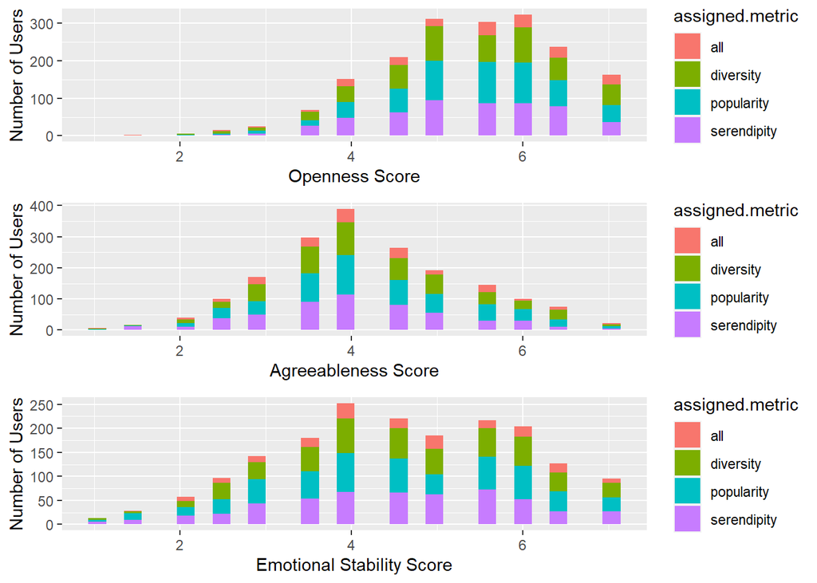

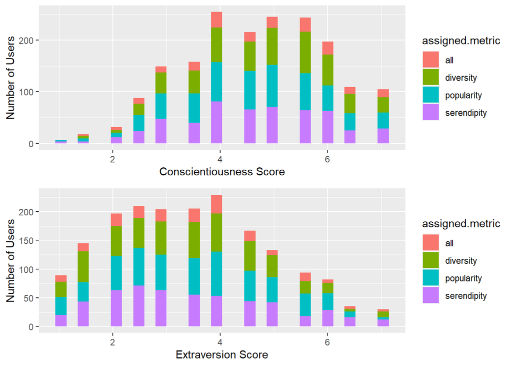

### Descriptive Statistics

We wanted to take the visualizations that were displayed in the histograms and look at values for central tendency and dispersion for each of the personality traits.

```
## [1] "Mean of Personality Traits"
```

```
##            openness       agreeableness emotional_stability   conscientiousness
##                 5.4                 4.2                 4.6                 4.6
##        extraversion
##                 3.5
```

```
## [1] "Median of Personality Traits"
```

```
##            openness       agreeableness emotional_stability   conscientiousness
##                 5.5                 4.0                 4.5                 4.5
##        extraversion
##                 3.5
```

```
## [1] "Mode of Personality Traits"
```

```
##            openness       agreeableness emotional_stability   conscientiousness
##                   5                   4                   4                   4
##        extraversion
##                   4
```

```
## [1] "Standard Deviation of Personality Traits"
```

```
##            openness       agreeableness emotional_stability   conscientiousness
##                 1.0                 1.2                 1.4                 1.3
##        extraversion
##                 1.5
```

```
## [1] "Range of Personality Traits"
```

```
##      openness agreeableness emotional_stability conscientiousness extraversion
## [1,]        1             1                   1                 1            1
## [2,]        7             7                   7                 7            7
```

```
## [1] "Skew of Personality Traits"
```

```
##            openness       agreeableness emotional_stability   conscientiousness
##               -0.57                0.17               -0.22               -0.17
##        extraversion
##                0.31
```

```
## [1] "Kurtosis of Personality Traits"
```

```
##            openness       agreeableness emotional_stability   conscientiousness
##                3.03                2.84                2.34                2.43
##        extraversion
##                2.36
```

#### 1. **Central Tendency:**

- While all Personality traits had fairly similar measures, Openness has the highest average score at 5.37, the highest median at 5.5, and the highest mode at 5.

#### 2. **Dispersion:**

- All ranges are the same as each trait has a max score of 7 and a minimum score of 1.
- Standard Deviations range from 1.0 to 1.5 with openness having the tightest standard deviation.
- Positive skew: Agreeableness and Extraversion have a positive skew which indicates that their mean is greater than their median.
- Negative skew: Opennes, Emotional Stability, and Conscientiousness have negative skew which indicates that their mean is less than their median.
- The greatest skew is for openness at -0.57 and Extraversion at 0.31.
- The kurtosis of a normal distribution is 3; any kurtosis <3 is playkurtic (tends to produce fewer and less extreme outliers than the normal distribution); any kurtosis >3 is thought to produce more outliers than the normal distribution.
- Each of the Personality traits, excpet Openness, has a kurtosis of less than three indicating that they produce fewer outliers and extreme values than a standard normal distribution.

## How do the numbers of users in each of the traits differ?

We next wanted to look at the numbers of users in each trait. Since each user is given a rating for every personality trait, we chose to break up these personality traits into zones. These zones are high scorers (score of 6-7), medium scorers (score of 3-5), and low scorers (score of 1-2).

#### 1. Filter each of the personality traits based on our described “zones” of high, medium, or low.

- **Number of Users with Personality Trait Scores of 6-7**

```
## Openness 435
```

```
## Agreeableness 110
```

```
## Emotional Stability 251
```

```
## Conscientiousness 227
```

```
## Extraversion 90
```

- **Number of Users with Personality Trait Scores of 3-5.5**

```
## Openness 602
```

```
## Agreeableness 830
```

```
## Emotional Stability 685
```

```
## Conscientiousness 748
```

```
## Extraversion 591
```

- **Number of Users with Personality Trait Scores of 1-2.5**

```
## Openness 15
```

```
## Agreeableness 112
```

```
## Emotional Stability 116
```

```
## Conscientiousness 77
```

```
## Extraversion 371
```

- **The trait with the highest number of users with low scores is Extraversion, Agreeableness has the most users with a medium score, and Openness has the most users with high scores. All personality traits have more users in a medium scoring category than in high or low categories.**
- **At this point, we feel we have looked into the differences in assigned score for each of the Personality traits sufficiently. There are some clear differences in the numbers of users with high, medium, or low scores; as well as differences in the central tendency and dispersion. These can all be predominantly visualized in the histograms that we started this section with.**
- *We will now switch our focus to looking at the Assigned Conditions given to each User as well as User satisfaction in their assigned movie list.*

## Assigned Condition and User Satisfaction

The assigned metric was used to curate lists of films for users to rate. Users received values of “diversity,” “popularity,” “serendipity,” or a default of “all.” In addition to the assigned metric, an assigned condition was used to scale the assigned metric. For example, users with an assigned metric of serendipity and an assigned condition of “high” would receive highly serendipitious movies to rate.

We expect to see the assigned metric provided some degree of customization in the list of movies sent to users, but also wanted to see if the addition of the assigned condition improved user satisfaction with the list of films. #### 1. What is the distribution of the assigned metric?

```
## [1] "Number of Users in Each Assigned Metric"
```

```
##         all   diversity  popularity serendipity
##         200         518         573         529
```

- **Results: Very few people have no assigned metric and most were given a list of “popular” movies to watch and rate.**

#### 2. What is the average rating by each assigned metric?

```
## [1] "Average Rating of all users grouped together:"
```

```
## [1] 3.37
```

```
## [1] "Average Rating by Each Assigned Metric"
```

```
##         all   diversity  popularity serendipity
##        3.41        3.37        3.38        3.35
```

- **Average ratings are very similar across assigned metrics and assigned metric category may not have had any influence in customizing the list of movies given to each User.**

#### 3. Number of Users in each assigned condition by assigned metric:

```
## [1] "Number of Users with assigned metric of 'diversity' by assigned condition"
```

```
##   high    low medium
##    175    169    174
```

```
## [1] "Number of Users with assigned metric of 'popularity' by assigned condition"
```

```
##   high    low medium
##    178    204    191
```

[output not shown]

```
##   high    low medium
##    198    160    171
```

- **For each assigned metric, the distribution of assigned condition appears to be uniform. This means as we examine the affect of assigned condition on ratings and user satisfaction our analysis will not be skewed due to a high percentage of users with a specific condition.**

#### 4. Distribution of ratings by each assigned metric:

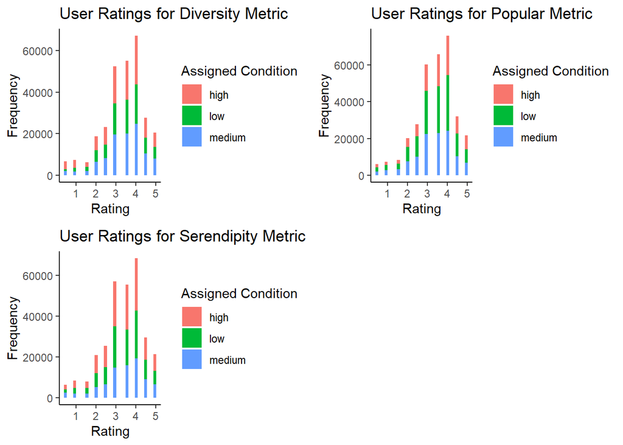

- **From the distributions of ratings for each assigned metric, it does not appear that any assigned condition resulted in higher ratings. See the values for each below.**

```
## [1] "Average ratings for diversity metric:"
```

```
##     high      low   medium
## 3.293245 3.394210 3.426506
```

```
## [1] "Average ratings for popularity metric:"
```

```
##     high      low   medium
## 3.458378 3.378094 3.319045
```

```
## [1] "Average ratings for serendipity metric:"
```

```
##     high      low   medium
## 3.319042 3.347073 3.383018
```

- **The percentage of ratings for high, low, and medium assigned conditions were consistent throughout the distributions of ratings.**
- **The customization with the assigned metric and condition did not affect user ratings. We then investigated what effected User film satisfaction.**

## User Satisfaction Analysis

Since customization with the assigned metric and condition did not seem to impact user ratings, we then investigated any possible relationship between user enjoyment and their list of films.

#### 1. What is the distribution of satisfaction?

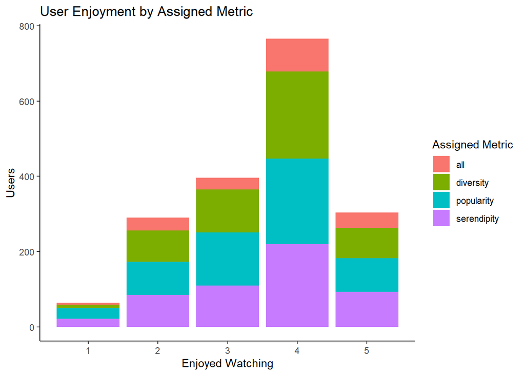

**Overall, the vast majority of users enjoyed the list of films they were assigned to rate. However, it does not appear that the assigned metric influenced whether users enjoyed their list of movies. The proportion of satisfied users is consistent for each of the enjoyment responses.**

- **We next examined the distribution of user satisfaction for each assigned metric by the assigned condition.**

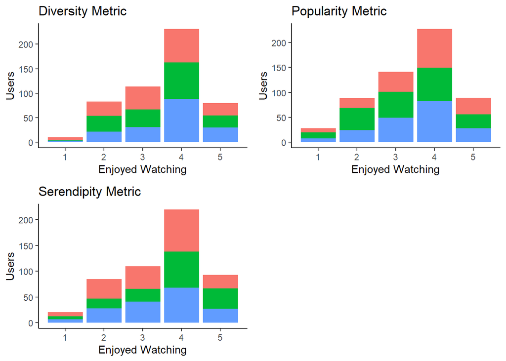

## Personality and User Rating

#### 1. Generate graphs of average user rating vs user’s personality scores.

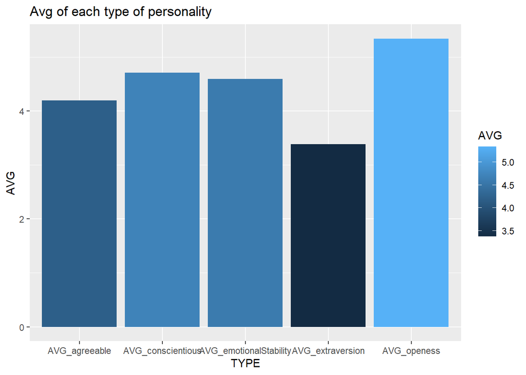

#### 2. It is possible that there are patterns that we are not seeing due to looking at too broad of group classifications. To delve into this, we decided to look just at users who had given a rating of five to 100 or more movies in their list. We utilized bar graphs to visualize any patterns.

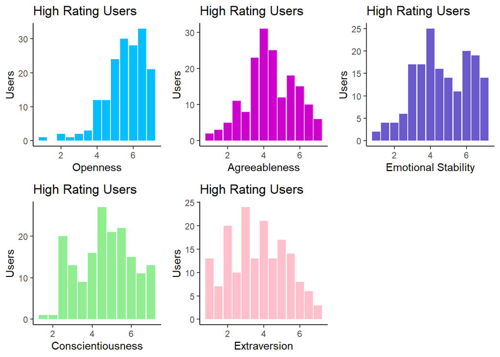

- **While these distributions may look different from each other, when compared to the distribution of users within each score, no new patterns emerged.**
- **We also wanted to see if there were noticeable differences when we grouped the user by filtering Personality traits by high or low score buckets.**

#### 1. Filter users by high/low scores in personality traits (High = score > average, Low = score < average).

#### 2. Create density diagram for predicted vs. actual rate base on the different types of personality.

#### 3. Clarify the difference between Predicted vs. actual rate based on the different types of personality.

- **In the below density plots, the vertical dashed lines represent the mean for each of the personality traits depicted. We are looking at density plots of high and low scoring users ratings.**

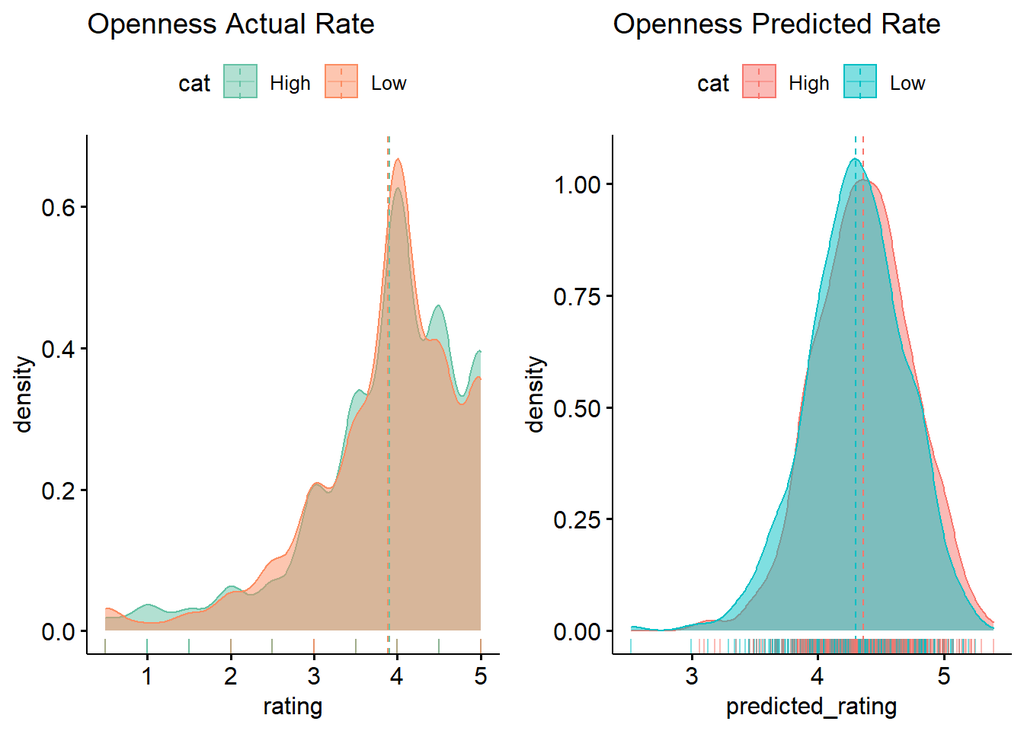

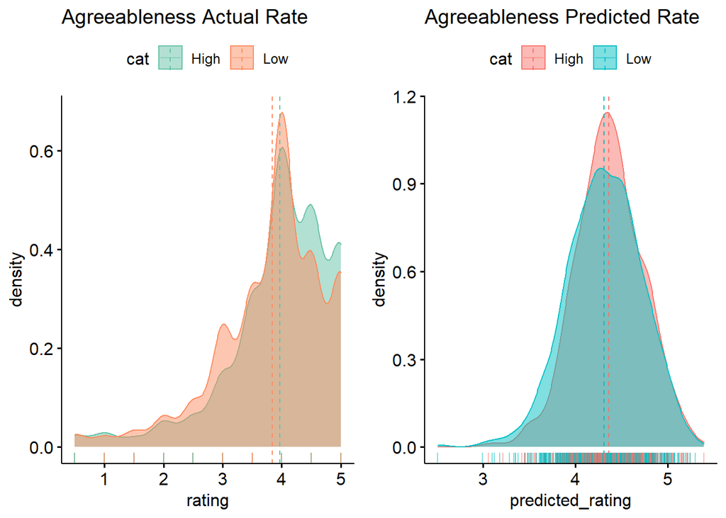

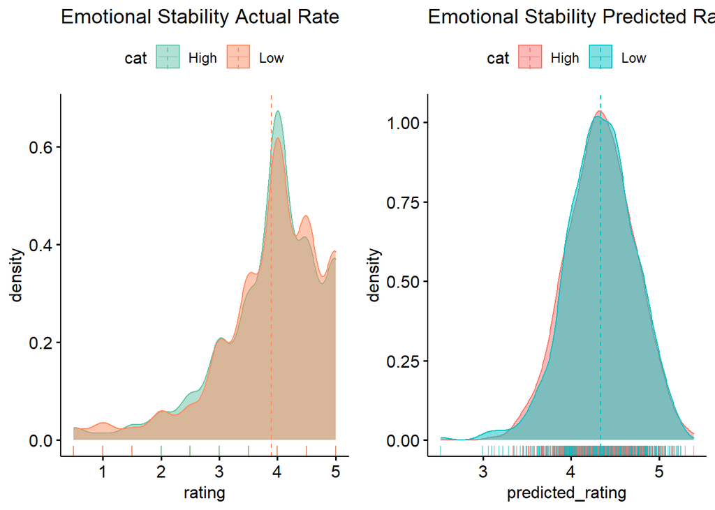

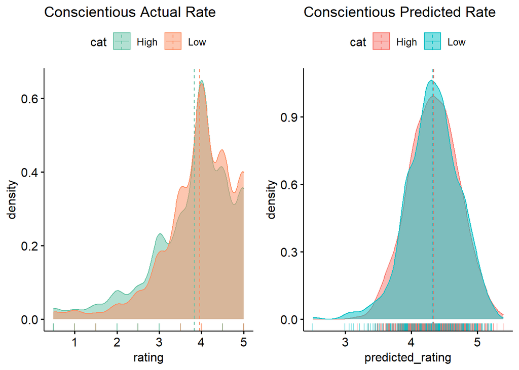

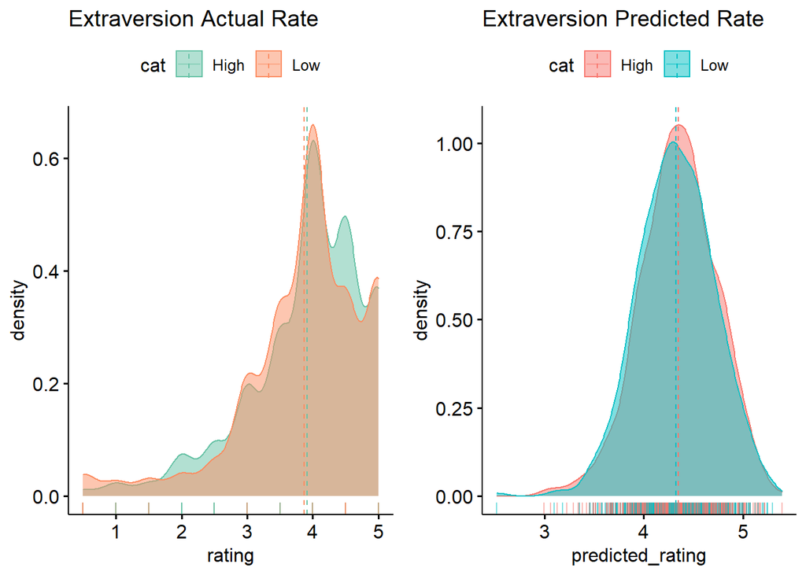

- **These density plots show that people with an extreme high level of openness scored above Average compared to the other 4 types of personality (agreeable, emotional stability, conscientious, and extraversion). Their predictive rates for their movies match best with their actual ratings.**
- **Now that we have explored the relationship between personality traits, assigned metrics, and assigned conditions with ratings and user satisfaction we will next explore the Predicted and Actual ratings.**

## Predicted and Actual Ratings

Each user was given over six thousand films to rate; this data was captured as their Actual Rating. Additionally, for each user, a random sample of 12 of their rated movies was chosen for the researchers to attempt to predict the ratings. We wanted to look at the differences between actual and predicted ratings to pull out any patterns that might occur.  
We found that the best way to truly see patterns was to use the “Bins” we created earlier of high, medium, and low scores for each of the personality traits.

#### 1. Separate the type of personality and making the diagram separately

#### 2. Categorize the data by high , medium and low utilizing ifelse statements.

#### 3. Set boundaries for predicted ratings.

#### 4. Number of Users in each Class

```
## # A tibble: 3 x 2
##   CLASS  openness_num_class
##   <fct>               <int>
## 1 Medium                602
## 2 High                  435
## 3 Low                    15
```

```
## # A tibble: 3 x 2
##   CLASS  agreeable_num_class
##   <fct>                <int>
## 1 Medium                 830
## 2 Low                    112
## 3 High                   110
```

```
## # A tibble: 3 x 2
##   CLASS  emotion_num_class
##   <fct>              <int>
## 1 Medium               685
## 2 High                 251
## 3 Low                  116
```

```
## # A tibble: 3 x 2
##   CLASS  concientious_num_class
##   <fct>                   <int>
## 1 Medium                    748
## 2 High                      227
## 3 Low                        77
```

```
## # A tibble: 3 x 2
##   CLASS  extraversion_num_class
##   <fct>                   <int>
## 1 Medium                    591
## 2 Low                       371
## 3 High                       90
```

#### 5. Create bar charts to visualize the distribution of number of Users in relation to the score they received being low, medium, or high.

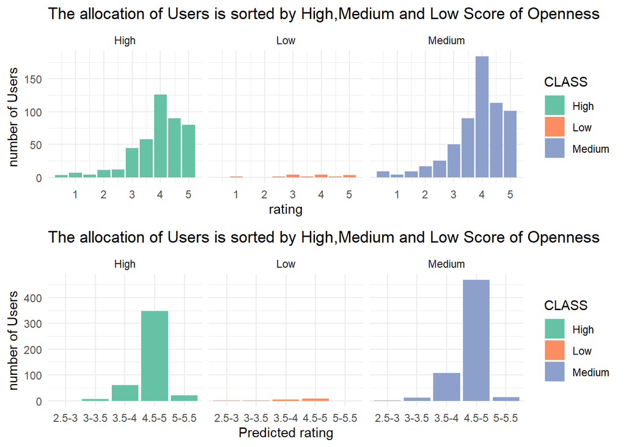

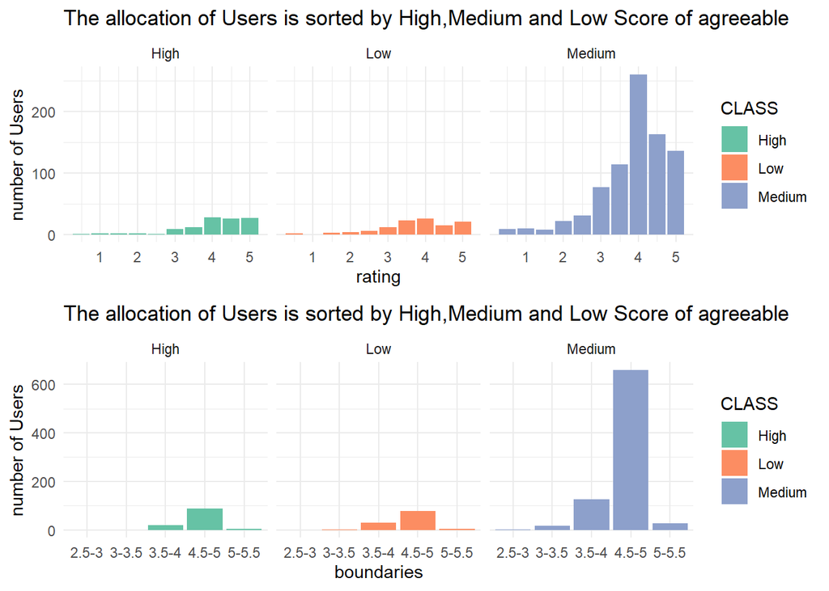

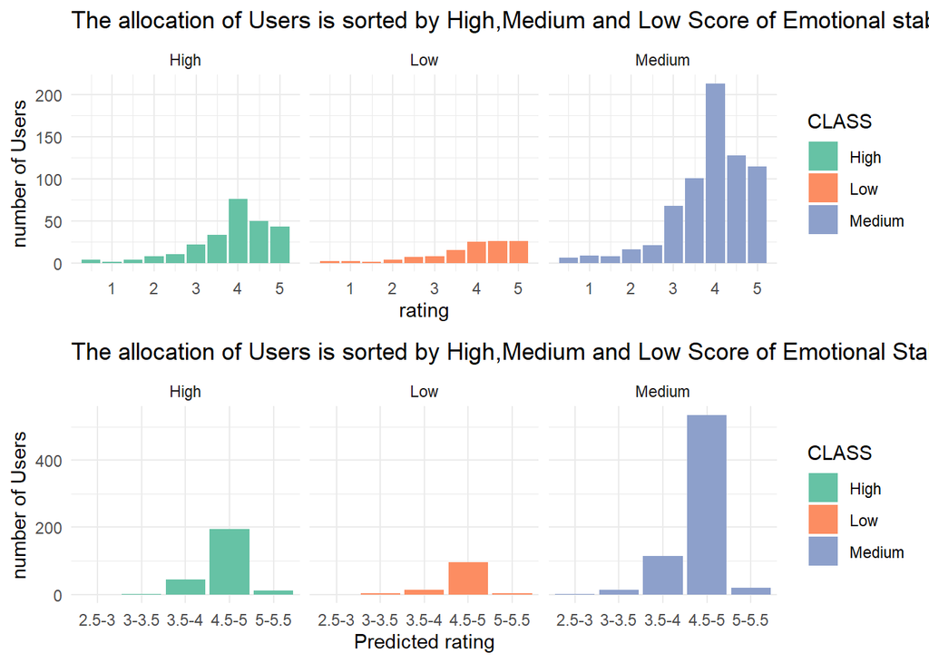

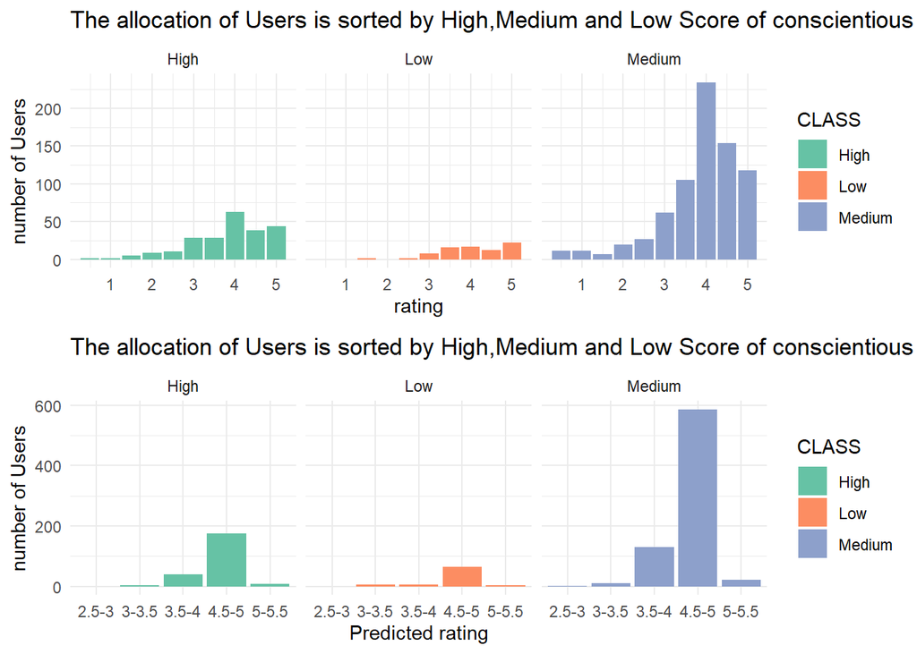

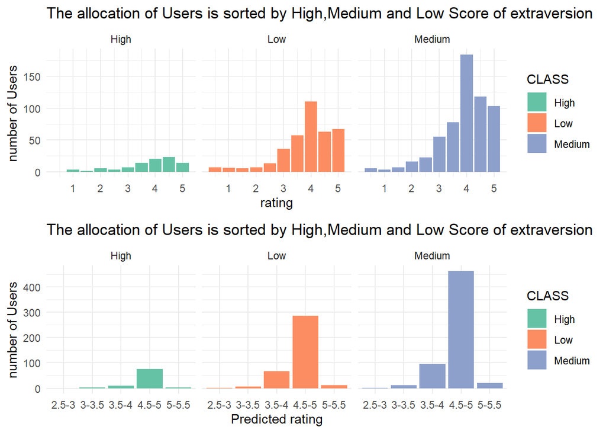

- **When users are grouped into categories of low, medium, and high by their personality traits we can see that the predicted rating pattern is similar to the actual ratings given by the users.**
- **More specifically, if someone were to score highly in any one of the personality traits, the likelihood of the predicted rating mirroring the actual rating increases.**
- For the agreeableness trait, the users are moderate (score 4). For the conscientious, the user is average (score 5). For the emotional stability, the users are average. And for the extraversion, the user is moderate (score4). For the extraversion, the users are moderate.
- After analyzing the differences between predicted and actual ratings in a few different ways, we wanted to move on to creating our own prediction models to see if we could generate results as close as their were.

## Explanatory Regression Models

While the original researchers for this study were able to generate a model for predicting user ratings from the personality traits, they came to the conclusion that their “prediction” was unable to explain the differences in User ratings, enjoyment and satisfaction.  
We wanted to attempted to create our own models starting with linear and multiple regression. While we expect to see similar results to theirs (our models will not explain what drivers user ratings with any confidence), we felt it was worth the effort to try.

#### 1. Linear Regression Models

- **Our dependent variable for all of the regression models is user ratings. We want to see if there is good indication of any of the Personality Trait Scores being the driver for these ratings.**
- **We chose to first look at each of the Personality traits individually. Agreeableness, then extroversion and emotional stability are the traits that are more likely to predict movie ratings. However, none of the R <sup>2</sup> values are high enough to suggest a these are good explanatory variables. In fact, the highest R <sup>2</sup> value was 0.003928. This was surprisingly low to us.**
- **Next, we wanted to see if combining any of the personality traits would lead to better explanatory power.**

#### 2. Multiple Regression Models

1. We looked at three separate multiple regression models:
- 1. Agreeableness + Extraversion:
- **R <sup>2</sup> of 0.005956**
- 2. Agreeableness + Extraversion + Emotional Stability:
- **R <sup>2</sup> of 0.006369**
- 3. Used all five of the personality traits to explain ratings:
- **R <sup>2</sup> of 0.007123**
- **See the best regression that was produced:**

```
##
## Call:
## lm(formula = rating ~ agreeableness + extraversion + emotional_stability +
##     conscientiousness + openness, data = RatingPerson)
##
## Residuals:
##     Min      1Q  Median      3Q     Max
## -3.1771 -0.4541  0.1243  0.6571  1.9410
##
## Coefficients:
##                       Estimate Std. Error t value Pr(>|t|)
## (Intercept)          3.1133192  0.0070771 439.911   <2e-16 ***
## agreeableness        0.0459786  0.0008571  53.643   <2e-16 ***
## extraversion         0.0325658  0.0007139  45.617   <2e-16 ***
## emotional_stability  0.0219205  0.0007726  28.373   <2e-16 ***
## conscientiousness   -0.0220033  0.0008172 -26.924   <2e-16 ***
## openness            -0.0080973  0.0009654  -8.387   <2e-16 ***
## ---
## Signif. codes:  0 '***' 0.001 '**' 0.01 '*' 0.05 '.' 0.1 ' ' 1
##
## Residual standard error: 1.006 on 1028745 degrees of freedom
## Multiple R-squared:  0.007128,   Adjusted R-squared:  0.007123
## F-statistic:  1477 on 5 and 1028745 DF,  p-value: < 2.2e-16
```

- **Conclusion: In every model, the R <sup>2</sup> values are extremely low, even though the p-values for each of the traits is significant. This tells us that while we can be confident that the inputs are impacting out output, they can explain very little of the variability in User ratings.**

## Create prediction models to test the accurancy of predicted rate.

#### 1. Generate the test and train groups for our data.

#### 2. Build a Model using KSVM & visualize the results.

- **We made seven different prediction models using eps-svr regression in the KSVM type model. We calculated the root mean square error of each and saw that all were close to 1.0. See an example below**

```
## [1] "Model 1 error value of actual rate for predication : 1.0041"
```

- **Below we show scatter plots of the variance between Predicted and Actual ratings for each personality type as generated by our KSVM models.**

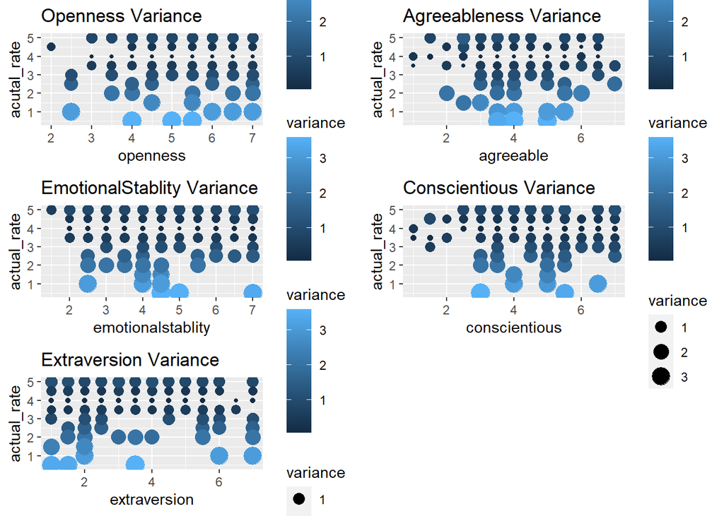

## Conclusions

**1. The Personality test that was administered to Users was able to separate Users into distinct groups.** **2. Assigned Metric and Assigned Condition were unable to explain variability in User Satisfaction.**  
**3. None of the Personality Traits, Assigned Metrics, or Assigned Conditions were able to explain differences in the User’ ratings.**  
**4. The researchers were able to predict ratings within around 0.5 points of the actual user ratings.** **5. Our regression models were unable to explain variability in User ratings.** **6. Our Predictive models were unable to reliably predict the ratings given by users.** **7. We wish that we had more time to try other predictive models to see if we could get the provided personality scores to better predict the data.**

#### **8. In conclusion, we do think that having users take a personality test is an interesting approach to being able to better predict user film choices. We do not think that these types of metrics will be able to predict the values of user ratings. We also think that having aditional data, such as user geographical data, would provide more insight for businesses considering using this type of information.